# DATA607finalprojectpresentation

jim lung

05-10-2017

# Introduction

In 2017, some financial companies uses advanced algorithms from data analystic to conduct 100% automatic finacial trading instead of human trading and analysis. I think this project is a good opportunity to help me figure out the relationship between different stock wave.

How the wave of Nasdaq index are affected by Amazon and Facebook?

# Research Questions

To explore how the wave of Nasdaq index are affected by Amazon and Facebook, I want to break down to different topics about the financial markets.

The statistics of daily historical stock prices & volumes for one year under this category, I will compare from Nasdaq index, Amazon and Facebooks.

The mainly resource I will use is http://www.nasdaq.com

# Proposed Sources

Both for short term and long term analysis, the related stock news will be used for analysis by sentiments in order to match for complexity.

Data scraping

- http://www.nasdaq.com/symbol/ndaq/historical
- http://www.nasdaq.com/symbol/amzn/historical
- http://www.nasdaq.com/symbol/fb/historical

Data sentiments

- http://www.nasdaq.com/symbol/ndaq/news-headlines
- http://www.nasdaq.com/symbol/amzn/news-headlines
- http://www.nasdaq.com/symbol/fb/news-headlines

# Data scraping

Scrapying method 1 - Using quantmod

```
## Version 0.4-0 included new data defaults. See ?getSymbols.
```

[output not shown]

```
## [1] "YHOO"
```

Scraping method 2 - Loading CSV

```
##         date  close       volume   open   high     low
## 1      16:00 952.95    3,171,374 952.80 957.89 950.200
## 2 2017/05/09 952.82 3256357.0000 952.80 957.89 950.200
## 3 2017/05/08 949.04 3406954.0000 940.95 949.05 939.210
## 4 2017/05/05 934.15 2863978.0000 940.52 940.79 930.300
## 5 2017/05/04 937.53 2413486.0000 944.75 945.00 934.215
## 6 2017/05/03 941.03 3578108.0000 946.00 946.00 935.900
```

Scraping method 3: To compare with the above method for scaping data, the method 3 can be retreive the most updated data for comparison, it may get the real time data, so we will use the method 3 for data analysis.

```
ddd <- function(i){


hkurl <- i

'ratings' <- function(hkurl)
  {
  require(XML)

hdoc <- getURLContent(hkurl)

# find all tables in webpage
hktables <- readHTMLTable(hdoc)

# find largest table and return as dataframe
columns <- unlist(lapply(hktables, function(t) dim(t)[2]))

df <- hktables[[max(columns)]]

return(df)
}

seriess <- ratings(hkurl)
colnames(seriess) <- c("Date","Open","High","Low","Close","Volume")
seriess
return(seriess)
}
```

# Function of calcuation of analysis

$$Range\quad of\quad daily\quad change\quad =\quad Close\quad -\quad Open$$

$$Rating\_ change\quad =\quad \frac { Close\quad -\quad Open }{ Open }$$

Dataset Example of Facebook:

```
    Date   Open   High    Low   Close   Volume   change  rating_change date_range
```

1 05/10/2017 151.49 152.59 150.21 150.48 16999575 -1.01 -0.006667107 2.38

2 05/09/2017 151.49 152.59 150.21 150.48 17381800 -1.01 -0.006667107 2.38

3 05/08/2017 150.71 151.08 149.74 151.06 15813350 0.35 0.002322341 1.34

4 05/05/2017 151.45 151.63 149.79 150.24 17104730 -1.21 -0.007989435 1.84

5 05/04/2017 150.17 151.52 148.72 150.85 36185180 0.68 0.004528201 2.80

6 05/03/2017 153.60 153.60 151.34 151.80 28301550 -1.80 -0.011718750 2.26

# Stock index comparsion

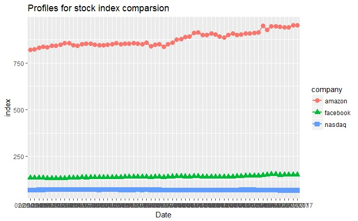

Stock index comparsion

# linear regression comparsion between nasdaq and amazon

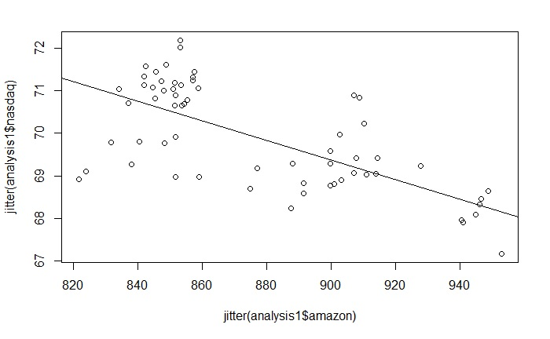

Nasdaq and amazon

# linear regression comparsion between nasdaq and facebook

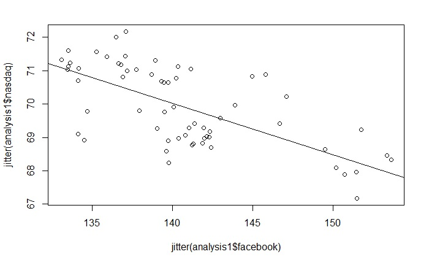

Nasdaq and facebook

# Stock rating comparsion

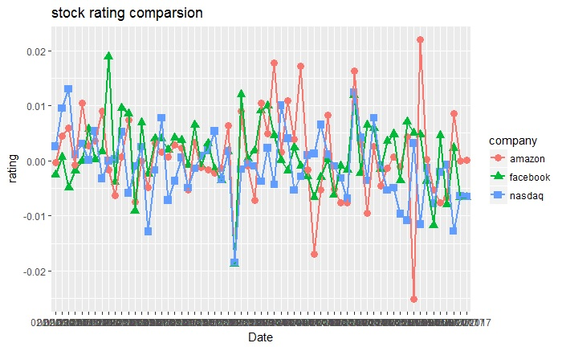

Stock rating comparsion

# The range of stock change comparsion

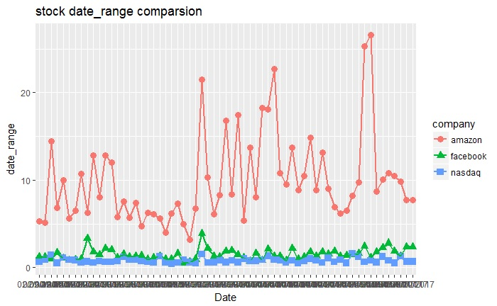

range of stock change

The wave of facebook and nasdaq seem to be more similar than amazon.

# sentiment analysis

Sentiment analysis from scraping most recent article about Amazon, Facebook and Nasdaq.

[figure not shown]

Amazon’s article

# Sentiment analysis from scraping most recent article

```
web <- function(i){

weblinks <- read_html(paste('https://www.nasdaq.com/symbol/',i,'/news-headlines',sep=""))

doc <- htmlParse(weblinks)

links <- xpathSApply(doc, "//a/@href")

#http://www.nasdaq.com/article/

webs <-unlist(str_extract_all(links, 'http://www.nasdaq.com/article.+'))
webs

}
```

[1] “http://www.nasdaq.com/article/4-stocks-im-never-selling-cm786315”

[2] “http://www.nasdaq.com/article/4-stocks-im-never-selling-cm786315”

[3] “http://www.nasdaq.com/article/the-first-thing-you-should-do-with-your-social-security-check-cm786333”

[4] “http://www.nasdaq.com/article/the-first-thing-you-should-do-with-your-social-security-check-cm786333”

[5] “http://www.nasdaq.com/article/bats-targets-nyse-and-nasdaq-endofday-volume-with-new-offering-20170508-01109”

[6] “http://www.nasdaq.com/article/us-economics-feds-bullard-current-funds-rate-reasonable-balance-sheet-unwind-could-start-in-2017-cm785162”

[7] “http://www.nasdaq.com/article/key-takeaways-from-ices-q1-earnings-cm784490”

[8] “http://www.nasdaq.com/article/a-drop-in-trading-volume-curbs-nasdaqs-results-cm783594”

[9] “http://www.nasdaq.com/article/intercontinental-exchange-ice-beats-q1-earnings-estimates-cm783595”

[10] “http://www.nasdaq.com/article/ice-allots-10-mln-for-regulatory-probes-earnings-rise-20170503-01190”

[11] “http://www.nasdaq.com/article/key-takeaways-from-cmes-q1-earnings-cm781544”

[12] “http://www.nasdaq.com/article/3-things-you-didnt-know-about-frontier-communications-corporation-cm781065”

[13] “http://www.nasdaq.com/article/key-takeaways-from-nasdaqs-q1-earnings-cm780749”

[14] “[http://www.nasdaq.com/article/cme-group-cme-q1-earnings-beat-revenues-miss-estimates-cm780387"rr](http://www.nasdaq.com/article/cme-group-cme-q1-earnings-beat-revenues-miss-estimates-cm780387%22rr)

# Using tibble function for sentiment each words:

A tibble: 252,936 ⊙ 3 company article word

1 amazon 1 doctype

2 amazon 1 html

3 amazon 1 html

4 amazon 1 lang

5 amazon 1 en

6 amazon 1 us

7 amazon 1 class

8 amazon 1 inner

9 amazon 1 news

10 amazon 1 story … with 252,926 more rows

A tibble: 251,425 ⊙ 3

```
company article    word

<fctr>   <int>   <chr>
```

1 facebook 1 doctype

2 facebook 1 html

3 facebook 1 html

A tibble: 245,628 ⊙ 3

company article word

1 nasdaq 1 doctype

2 nasdaq 1 html

3 nasdaq 1 html

# Using get sentiments - nrc for analysis

Amazon:

A tibble: 10 ⊙ 2

```
 sentiment     n

      <chr> <int>
```

1 positive 11885

2 trust 6574

3 negative 6104

4 anticipation 3104

5 sadness 2849

6 fear 2630

7 joy 2560

8 anger 2335

9 surprise 1870

10 disgust 1457

Facebook:

A tibble: 10 ⊙ 2

```
  sentiment     n

      <chr> <int>
```

1 positive 11704

2 trust 6454

3 negative 5988

4 anticipation 3008

5 sadness 2798

6 fear 2597

7 joy 2511

8 anger 2309

9 surprise 1830

10 disgust 1476

Nasdaq:

A tibble: 10 ⊙ 2

```
  sentiment     n

      <chr> <int>
```

1 positive 11691

2 trust 6403

3 negative 5941

4 anticipation 3007

5 sadness 2775

6 fear 2604

7 joy 2465

8 anger 2276

9 surprise 1821

10 disgust 1400

# Visualization

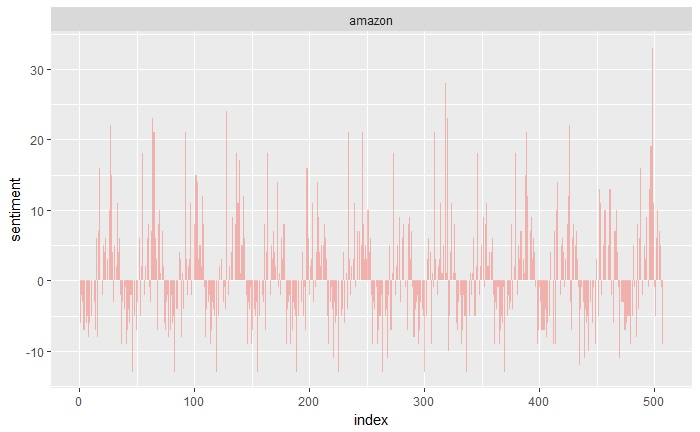

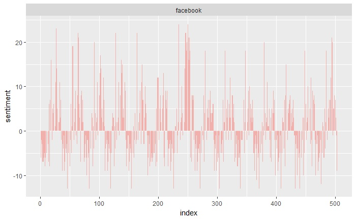

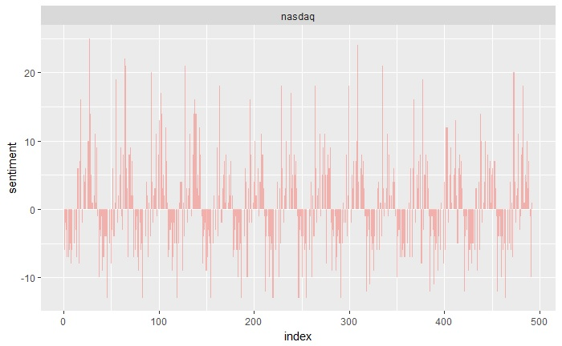

# Conclusion